# NYC Campaign Finance Network Analysis

Natalie O’Shea and Millie Olivia Symns

06 March 2022

## Data Preparation

First we need to load our data processing libraries and pull data from the NYC Open Data. We also check to make sure there are no duplicated candidate names by checking that the length of unique candidate ids matches the length of unique candidate names. This let’s us know that we can refer to each candidate by name in subsequent steps without worrying about whether there are any inconsistencies between candidate names and ids.

```r
# install packages (uncomment and run if necessary)
# install.packages(c("tidyverse", "igraph", "ggraph", "RSocrata", "networkD3"))

# load libraries
library(tidyverse)
library(igraph)
library(ggraph)

# load data from NYC Open Data
contributions <- RSocrata::read.socrata("https://data.cityofnewyork.us/resource/rjkp-yttg.json")

# check that length of unique ids equals length of unique names
length(unique(contributions$recipid))
```

```
## [1] 205
```

```r
length(unique(contributions$recipname))
```

```
## [1] 205
```

Next, let’s wrangle the campaign contribution data into a network-friendly data format. First, we simplify the contributions data frame by only saving relevant columns, removing contribution amounts less than or equal to zero, and merging multiple donations to the same candidate.

```r
# across all races
contributions_simple <- contributions %>%
  select(recipname, name, c_code, boroughcd, amnt) %>%
  # add filters for later exploration
  filter(c_code %in% unique(contributions$c_code),
         boroughcd %in% unique(contributions$boroughcd),
         amnt > 0) %>%
  # set amount to numeric
  mutate(amnt = as.numeric(amnt)) %>%
  # summarize multiple donations from one individual to the same candidate
  group_by(recipname, name) %>%
  summarize(amnt = sum(amnt)) %>%
  ungroup()
```

Next, we generate a list of individuals that contributed to more than one campaign during the 2021 election cycle. We then filter the simplified contributions data frame to only include these “double dippers” and only look at relatively large donations (an arbitrary threshold we set at $1500).

```r
# find individuals that contributed to more than one candidate
double_dippers <- contributions_simple %>%
  group_by(name) %>%
  summarize(n = n()) %>%
  filter(n > 1) %>%
  arrange(desc(n)) %>%
  ungroup()

# save contributions only from individuals that contributed to more than one candidate
network_data <- contributions_simple %>%
  filter(name %in% double_dippers$name) %>%
  rename(
    "candidate" = recipname,
    "contributor" = name,
    "amount" = amnt
  ) %>%
  # only look at large donations
  filter(amount >= 1500)

# view first few rows of data
head(network_data)
```

```
## # A tibble: 6 x 3
##   candidate     contributor       amount
##   <chr>         <chr>              <dbl>
## 1 Abreu, Shaun  Abreu, Shaun        1905
## 2 Adams, Eric L Adjmi, Harry        5000
## 3 Adams, Eric L Ahmad, Ijaz         5000
## 4 Adams, Eric L Albstein, Andrew    5100
## 5 Adams, Eric L Alexander, Kelvin   2000
## 6 Adams, Eric L Argento, Anthony    5100
```

### Create Network Dataframe

Finally, we can create a dataframe of all possible combinations of candidates and calculate how many times an individual contributed to each of their campaigns. For instance, if an individual contributed to both both the Eric Adams and Scott Stringer campaigns, we count that as a shared donation under the `donations` column.

```r
# create a network of shared donations
candidate_network <- unique(network_data$candidate) %>%
  # create matrix of all possible candidate combinations
  combn(2) %>%
  # transpose matrix into long format
  t() %>%
  # make data frame
  data.frame() %>%
  # rename columns
  rename(
    "from" = X1,
    "to" = X2
  ) %>%
  # count length of intersections of candidates from a single contributor
  mutate(donations = map2_dbl(from, to, ~length(intersect(network_data$contributor[network_data$candidate == .x],
                                                          network_data$contributor[network_data$candidate == .y])))) %>%
  # remove rows with no overlapping donations
  filter(donations > 0) %>%
  # arrange in descending order of shared donations
  arrange(desc(donations))

# view first few rows of data
head(candidate_network)
```

```
##                from                     to donations
## 1     Adams, Eric L      Stringer, Scott M        12
## 2   Diaz Jr., Ruben Salamanca, Jr., Rafael        12
## 3   Diaz Jr., Ruben      Stringer, Scott M         8
## 4 Stringer, Scott M      Van Bramer, James         7
## 5 Benjamin, Brian A      Stringer, Scott M         5
## 6     Katz, Melinda      Stringer, Scott M         5
```

## Data Visualization

### Heatmap

Before we generate a network graph, we might simply want to plot the number of shared donations between candidates as a heatmap.

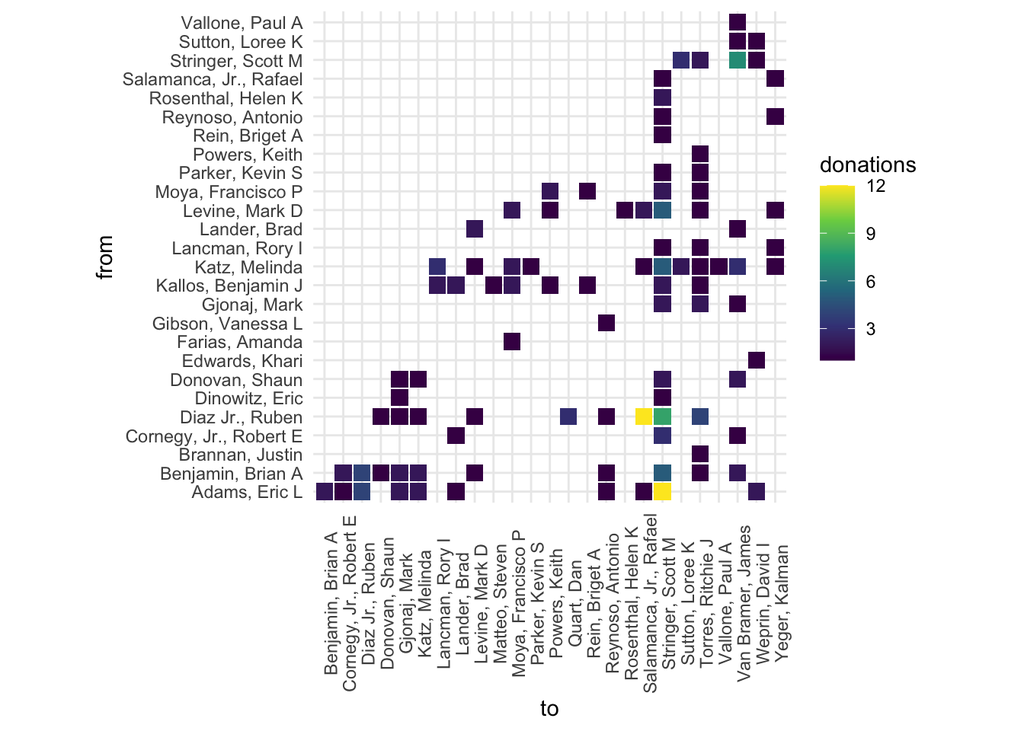

```r
# reorder plotting data in alphabetical order
plot_df <- candidate_network %>%
  arrange(from, to)

# create headmap
ggplot(plot_df, aes(to, from, fill= donations)) +
  geom_tile(aes(width=0.9, height=0.9)) +
  # force squares
  coord_equal() +
  # use colorblind-friendly viridis color palette
  scale_fill_viridis_c() +
  theme_minimal() +
  # rotate x axis text
  theme(axis.text.x = element_text(angle = 90))
```

### Network Graph

```r
# visualize
candidate_network %>%
  networkD3::simpleNetwork()
```

[interactive chart not shown]

This graph is fun to play with but not super informative. Let’s do a little additional network analysis to learn more about the network of large campaign contributions in New York City.

## Network Analysis

### Calculate Centrality

We can calculate and visualize node centrality quite easily using the `igraph` package. Individuals with high eigen values (a measure of centrality) are the most central to the network and received shared donations with the largest numbers of other candidates. Below, we label only individuals with an eigen value greater than 0.8.

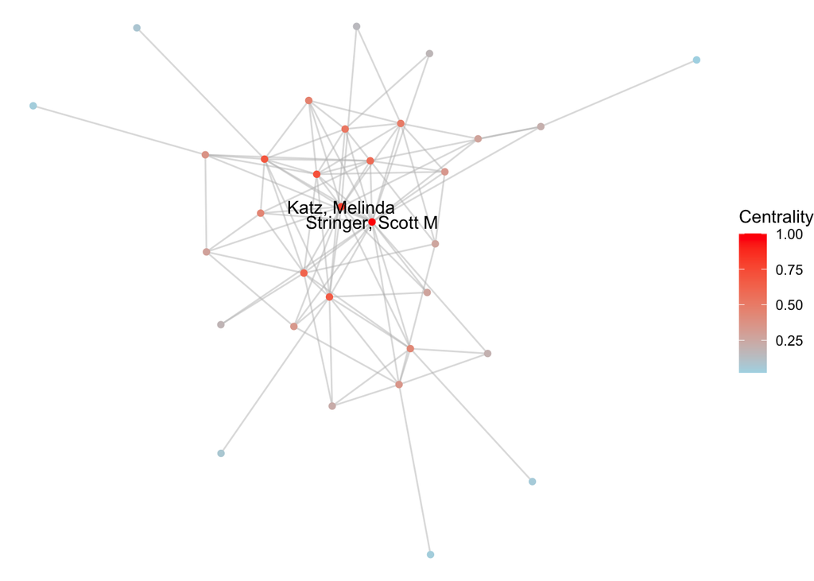

```r
# create graph object
graph_df <- candidate_network %>%
  igraph::graph_from_data_frame(directed = FALSE)

# set centralities as vertex properties
V(graph_df)$degree <- degree(graph_df)
V(graph_df)$betweenness <- betweenness(graph_df)
V(graph_df)$eigen <- eigen_centrality(graph_df)$vector

# visualize node centrality
ggraph(graph_df, layout = "fr") +
  geom_edge_link(color = "gray", alpha = 0.5,
                 show.legend = FALSE) +
  geom_node_point(aes(color = eigen)) +
  scale_color_gradient(low = "lightblue", high = "red") +
  geom_node_text(aes(label = ifelse(eigen > 0.8, name, NA))) +
  labs(color = "Centrality") +
  theme_void()
```

### Detect Communities

Finally, we can detect communities within our network using the Louvain algorithm, which maximizes the density of connections within subsets of individuals within the network.

```r
# detect communities using Louvain algorithm
communities <- cluster_louvain(graph_df)

# assign as a vertex property
V(graph_df)$community <- membership(communities)

# number and size of communities detected
sizes(communities)
```

```
## Community sizes
##  1  2  3  4
## 10  8 11  3
```

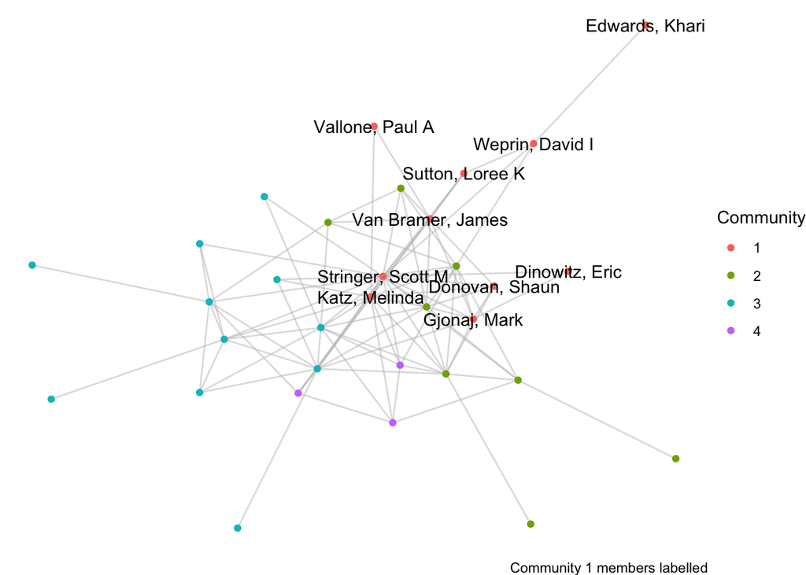

```r
# visualize communities
ggraph(graph_df, layout = "fr") +
  geom_edge_link(color = "gray", alpha = 0.5, show.legend = FALSE) +
  geom_node_point(aes(color = as.factor(community))) +
  geom_node_text(aes(label = ifelse(community == 1, name, NA))) +
  labs(color = "Community",
       caption = "Community 1 members labelled") +
  theme_void()
```

## Play Time!

Congratulations, you just took a dataset from the NYC Open Data Portal, created a network from it, and analyzed the properties of that network all within an hour… that’s no small feat! Feel free to use your remaining workshop time to play with the techniques you just learned. Some suggestions of what you might want to explore:

- Alter some of the parameters of the above analysis. How do your results change when you look only at small donations (e.g. <$50)? You might even take a look at the [data dictionary](https://data.cityofnewyork.us/api/views/rjkp-yttg/files/9d7a9ca4-e4c5-4aa3-86c0-9777889842e9?download=true&filename=Data_Dictionary_Contributions.xlsx) and filter your results to only look at certain contributor types (e.g. labor unions: EMPO in the c_code column) or only contributions coming from outside the city (“Z” in the boroughcd column).
- Explore some of the [other datasets available on the NYC Open Data Portal](https://opendata.cityofnewyork.us/data/#datasetscategory) and see if you can find additional datasets that might be interesting to explore using network analysis!